# Exploratory Data Analysis: `starwars`

Eugene Joh

Wednesday, December 05, 2018

# Overview

This parameterized markdown file is a standarized exploratory analysis report, examining the data type, structure, missing values, unique values, summary statistics for continuous and categorical variables contained within a `data.frame` object.

This does not support `date-time` varaibles such as `POSIXct` or `Date`, but will eventually move to support all data types typically found in `data.frame` in the R environment.

# Data Structure

Dataset Dimensions

| Name | Number of Columns | Number of Rows | Number of Elements | Memory Allocation |
| --- | --- | --- | --- | --- |
| starwars | 13 | 87 | 1’131 | 55.3 Kb |

Dataset Variable Class and Missing Values

| Variable | Class | missing |
| --- | --- | --- |
| name | character | 0 |
| height | integer | 6 |
| mass | numeric | 28 |
| hair_color | character | 5 |
| skin_color | character | 0 |
| eye_color | character | 0 |
| birth_year | numeric | 44 |
| gender | character | 3 |
| homeworld | character | 10 |
| species | character | 5 |
| films | list | 0 |
| vehicles | list | 0 |
| starships | list | 0 |

# Missing Values, Data Type, Unique Values

## Table

The table below displays the data type, counts/proportion of missing values `NA`, and whether the data is labelled or not.

|  | Variable | Missing (n) | Missing (%) | Exist (%) | Data Type | Labelled |
| --- | --- | --- | --- | --- | --- | --- |
| 1 | name | 0 | 0 | 100 | character | False |
| 2 | height | 6 | 6.9 | 93.1 | integer | False |
| 3 | mass | 28 | 32.18 | 67.82 | numeric | False |
| 4 | hair_color | 5 | 5.75 | 94.25 | character | False |
| 5 | skin_color | 0 | 0 | 100 | character | False |
| 6 | eye_color | 0 | 0 | 100 | character | False |
| 7 | birth_year | 44 | 50.57 | 49.43 | numeric | False |
| 8 | gender | 3 | 3.45 | 96.55 | character | False |
| 9 | homeworld | 10 | 11.49 | 88.51 | character | False |
| 10 | species | 5 | 5.75 | 94.25 | character | False |

[output cut: 3 more lines]

## Plot

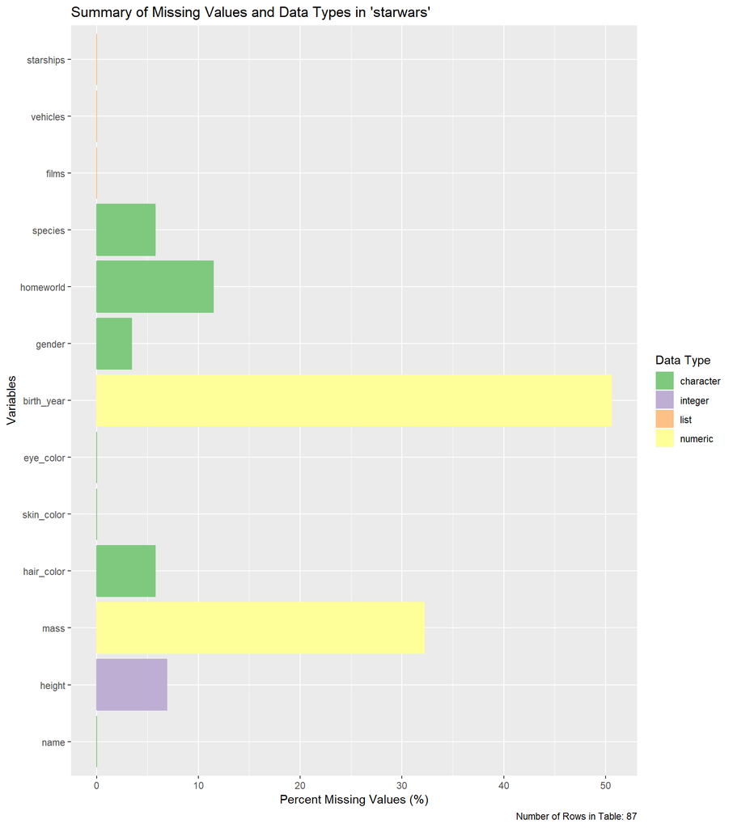

## Unique Values

|  | Variable | Counts | Percentage of Total Rows |
| --- | --- | --- | --- |
| 1 | name | 87 | 100 |
| 2 | height | 46 | 52.87 |
| 3 | mass | 39 | 44.83 |
| 4 | hair_color | 13 | 14.94 |
| 5 | skin_color | 31 | 35.63 |
| 6 | eye_color | 15 | 17.24 |
| 7 | birth_year | 37 | 42.53 |
| 8 | gender | 5 | 5.75 |
| 9 | homeworld | 49 | 56.32 |
| 10 | species | 38 | 43.68 |

[output cut: 3 more lines]

# Variable Content

This section contains an analysis of the variable content composition by describing the type of data content that exist based on **numeric** values, **character** values, **punctuation** or **symbols**, and **blank** space. This is especially useful when data types are not identified or misclassified.

## Only Numbers

**only_numbs** reports the number of rows that contain only digits `"^[0-9]{1,}$"` and **numpercent** is the respective percentage. **digits_min** and **digits_max** display the length of the digits found in the variable, **digits_eq** is a logical statment of whether the mix and max are equal.

|  | variable | only_numbs | n_row | numpercent | digits_min | digits_max | digits_eq |
| --- | --- | --- | --- | --- | --- | --- | --- |
| 1 | name | 0 | 87 | 0 |  |  | False |
| 2 | height | 81 | 87 | 93.103 | 2 | 3 | False |
| 3 | mass | 59 | 87 | 67.816 | 2 | 4 | False |
| 4 | hair_color | 0 | 87 | 0 |  |  | False |
| 5 | skin_color | 0 | 87 | 0 |  |  | False |
| 6 | eye_color | 0 | 87 | 0 |  |  | False |
| 7 | birth_year | 43 | 87 | 49.425 | 1 | 3 | False |
| 8 | gender | 0 | 87 | 0 |  |  | False |
| 9 | homeworld | 0 | 87 | 0 |  |  | False |
| 10 | species | 0 | 87 | 0 |  |  | False |

[output cut: 3 more lines]

## Only Character

**only_char** reports the number of rows that contain only characters `"^[A-z]{1,}"` and **charpercent** is the respective percentage.

|  | variable | only_char | n_row | charpercent |
| --- | --- | --- | --- | --- |
| 1 | name | 15 | 87 | 17.241 |
| 2 | height | 0 | 87 | 0 |
| 3 | mass | 0 | 87 | 0 |
| 4 | hair_color | 79 | 87 | 90.805 |
| 5 | skin_color | 71 | 87 | 81.609 |
| 6 | eye_color | 84 | 87 | 96.552 |
| 7 | birth_year | 0 | 87 | 0 |
| 8 | gender | 84 | 87 | 96.552 |
| 9 | homeworld | 69 | 87 | 79.31 |
| 10 | species | 76 | 87 | 87.356 |

[output cut: 3 more lines]

## Only Punctuation

**only_punc** reports the number of rows that contain only punctuation or symbols `"^\\W+$"` and **puncpercentage** is the respective percentage.

|  | variable | only_punc | n_row | puncpercent |
| --- | --- | --- | --- | --- |
| 1 | name | 0 | 87 | 0 |
| 2 | height | 0 | 87 | 0 |
| 3 | mass | 0 | 87 | 0 |
| 4 | hair_color | 0 | 87 | 0 |
| 5 | skin_color | 0 | 87 | 0 |
| 6 | eye_color | 0 | 87 | 0 |
| 7 | birth_year | 0 | 87 | 0 |
| 8 | gender | 0 | 87 | 0 |
| 9 | homeworld | 0 | 87 | 0 |
| 10 | species | 0 | 87 | 0 |

[output cut: 3 more lines]

## Only Blanks

**only_blanks** reports the number of rows that contain a blank ("") `"^\\s{0}$"` and **blankspercent** is the respective percentage. **only_wspace** reports the number of rows that contain any white-space, including a blank `"^\\s*$"` and **wspacepercent** is the respective percentage.

|  | variable | only_blanks | blankspercent | only_wspace | wspacepercent |
| --- | --- | --- | --- | --- | --- |
| 1 | name | 0 | 0 | 0 | 0 |
| 2 | height | 0 | 0 | 0 | 0 |
| 3 | mass | 0 | 0 | 0 | 0 |
| 4 | hair_color | 0 | 0 | 0 | 0 |
| 5 | skin_color | 0 | 0 | 0 | 0 |
| 6 | eye_color | 0 | 0 | 0 | 0 |
| 7 | birth_year | 0 | 0 | 0 | 0 |
| 8 | gender | 0 | 0 | 0 | 0 |
| 9 | homeworld | 0 | 0 | 0 | 0 |
| 10 | species | 0 | 0 | 0 | 0 |

[output cut: 3 more lines]

## All Types

|  | variable | only_numbs | numpercent | digits_min | digits_max | digits_eq | only_char | charpercent | only_punc | puncpercent | only_blanks | blankspercent | only_wspace | wspacepercent |
| --- | --- | --- | --- | --- | --- | --- | --- | --- | --- | --- | --- | --- | --- | --- |
| 1 | name | 0 | 0 |  |  | False | 15 | 17.241 | 0 | 0 | 0 | 0 | 0 | 0 |
| 2 | height | 81 | 93.103 | 2 | 3 | False | 0 | 0 | 0 | 0 | 0 | 0 | 0 | 0 |
| 3 | mass | 59 | 67.816 | 2 | 4 | False | 0 | 0 | 0 | 0 | 0 | 0 | 0 | 0 |
| 4 | hair_color | 0 | 0 |  |  | False | 79 | 90.805 | 0 | 0 | 0 | 0 | 0 | 0 |
| 5 | skin_color | 0 | 0 |  |  | False | 71 | 81.609 | 0 | 0 | 0 | 0 | 0 | 0 |
| 6 | eye_color | 0 | 0 |  |  | False | 84 | 96.552 | 0 | 0 | 0 | 0 | 0 | 0 |
| 7 | birth_year | 43 | 49.425 | 1 | 3 | False | 0 | 0 | 0 | 0 | 0 | 0 | 0 | 0 |
| 8 | gender | 0 | 0 |  |  | False | 84 | 96.552 | 0 | 0 | 0 | 0 | 0 | 0 |
| 9 | homeworld | 0 | 0 |  |  | False | 69 | 79.31 | 0 | 0 | 0 | 0 | 0 | 0 |
| 10 | species | 0 | 0 |  |  | False | 76 | 87.356 | 0 | 0 | 0 | 0 | 0 | 0 |

[output cut: 3 more lines]

# Variable Content Plot

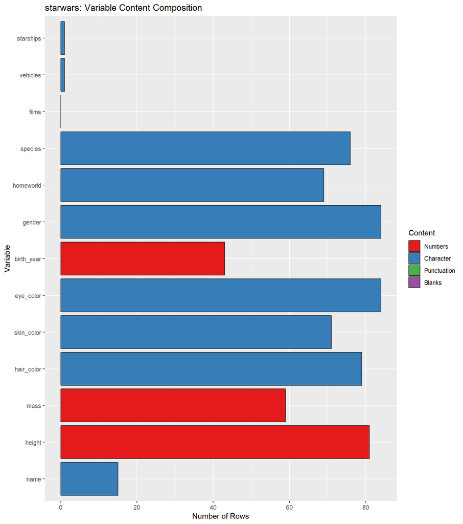

# Continuous Variables

## height

Summary Statistics for height

| Min | Mean | Median | Max | Standard Deviation |
| --- | --- | --- | --- | --- |
| 66 | 174.36 | NA | 264 | 34.77 |

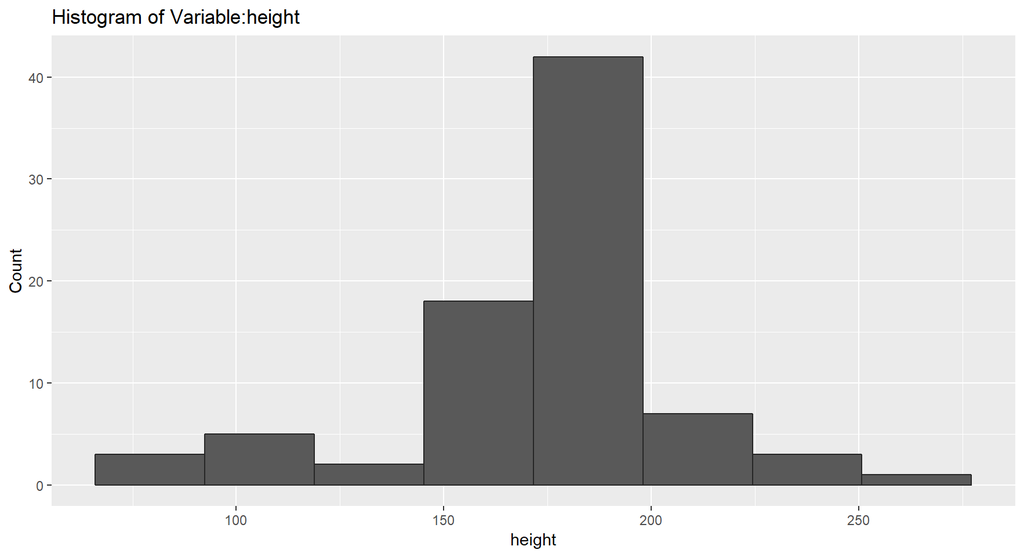

## mass

Summary Statistics for mass

| Min | Mean | Median | Max | Standard Deviation |
| --- | --- | --- | --- | --- |
| 15 | 97.31 | NA | 1358 | 169.46 |

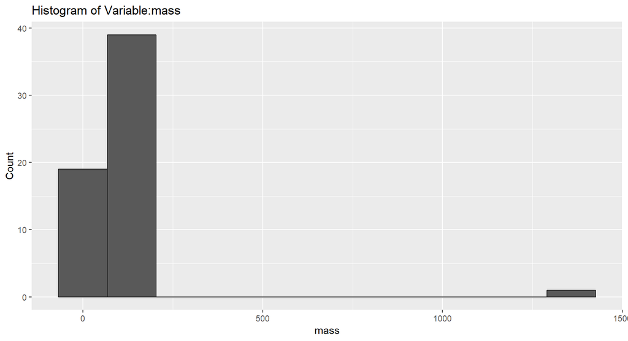

## birth_year

Summary Statistics for birth_year

| Min | Mean | Median | Max | Standard Deviation |
| --- | --- | --- | --- | --- |
| 8 | 87.57 | NA | 896 | 154.69 |

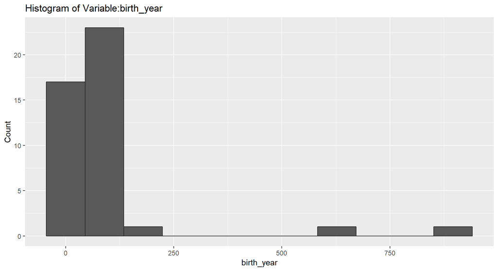

```r
if (length(names(dplyr::select_if(params$dat, funs(is.character(.) | is.factor(.))))) == 0) {
  cat_log <- FALSE
}
```

# Categorical Variables

## name

Counts and Proportion for Top 10: name

| name | n | percent |
| --- | --- | --- |
| Ackbar | 1 | 1.15 |
| Adi Gallia | 1 | 1.15 |
| Anakin Skywalker | 1 | 1.15 |
| Arvel Crynyd | 1 | 1.15 |
| Ayla Secura | 1 | 1.15 |
| Bail Prestor Organa | 1 | 1.15 |
| Barriss Offee | 1 | 1.15 |
| BB8 | 1 | 1.15 |
| Ben Quadinaros | 1 | 1.15 |
| Beru Whitesun lars | 1 | 1.15 |

[figure not shown]

## hair_color

Counts and Proportion for Top 10: hair_color

| hair_color | n | percent |
| --- | --- | --- |
| none | 37 | 42.53 |
| brown | 18 | 20.69 |
| black | 13 | 14.94 |
| NA | 5 | 5.75 |
| white | 4 | 4.60 |
| blond | 3 | 3.45 |
| auburn | 1 | 1.15 |
| auburn, grey | 1 | 1.15 |
| auburn, white | 1 | 1.15 |
| blonde | 1 | 1.15 |

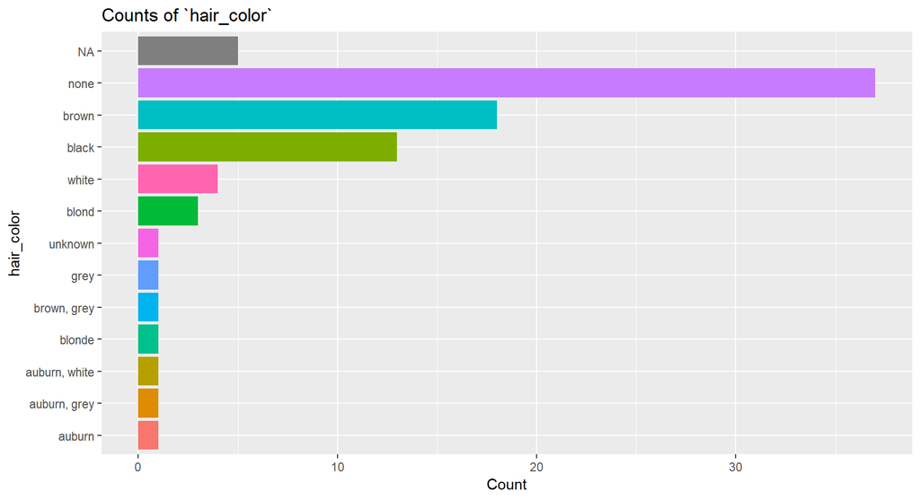

## skin_color

Counts and Proportion for Top 10: skin_color

| skin_color | n | percent |
| --- | --- | --- |
| fair | 17 | 19.54 |
| light | 11 | 12.64 |
| dark | 6 | 6.90 |
| green | 6 | 6.90 |
| grey | 6 | 6.90 |
| pale | 5 | 5.75 |
| brown | 4 | 4.60 |
| blue | 2 | 2.30 |
| blue, grey | 2 | 2.30 |
| orange | 2 | 2.30 |

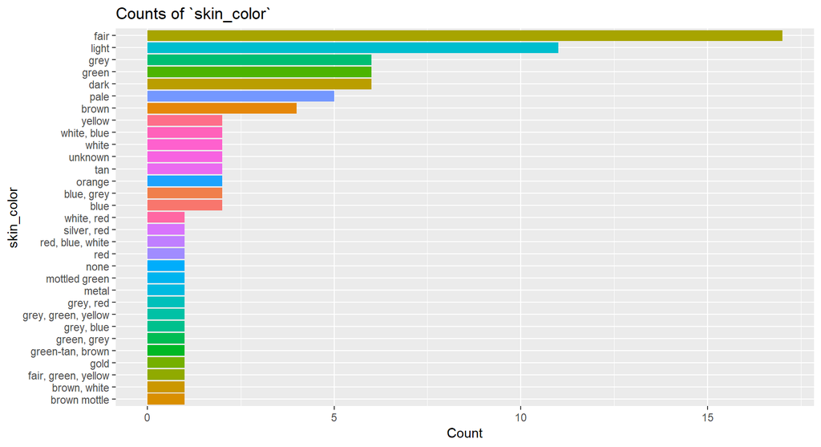

## eye_color

Counts and Proportion for Top 10: eye_color

| eye_color | n | percent |
| --- | --- | --- |
| brown | 21 | 24.14 |
| blue | 19 | 21.84 |
| yellow | 11 | 12.64 |
| black | 10 | 11.49 |
| orange | 8 | 9.20 |
| red | 5 | 5.75 |
| hazel | 3 | 3.45 |
| unknown | 3 | 3.45 |
| blue-gray | 1 | 1.15 |
| dark | 1 | 1.15 |

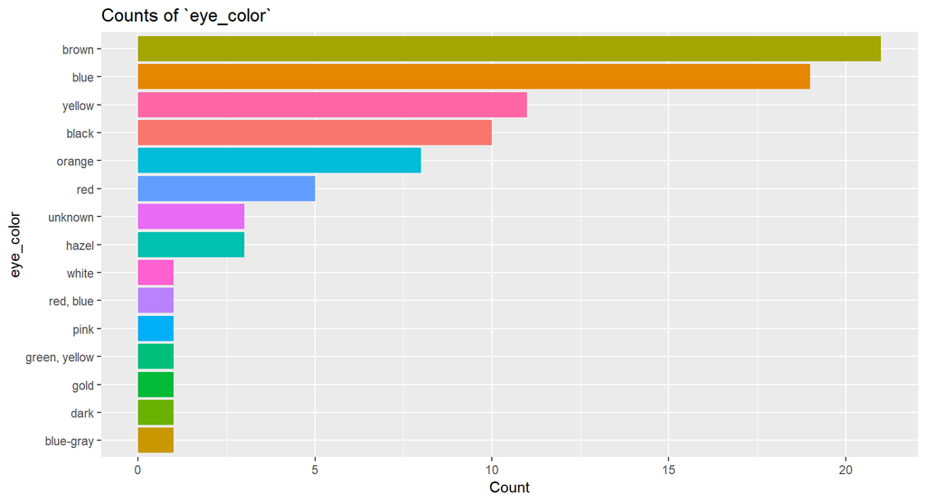

## gender

Counts and Proportion for Top 10: gender

| gender | n | percent |
| --- | --- | --- |
| male | 62 | 71.26 |
| female | 19 | 21.84 |
| NA | 3 | 3.45 |
| none | 2 | 2.30 |
| hermaphrodite | 1 | 1.15 |

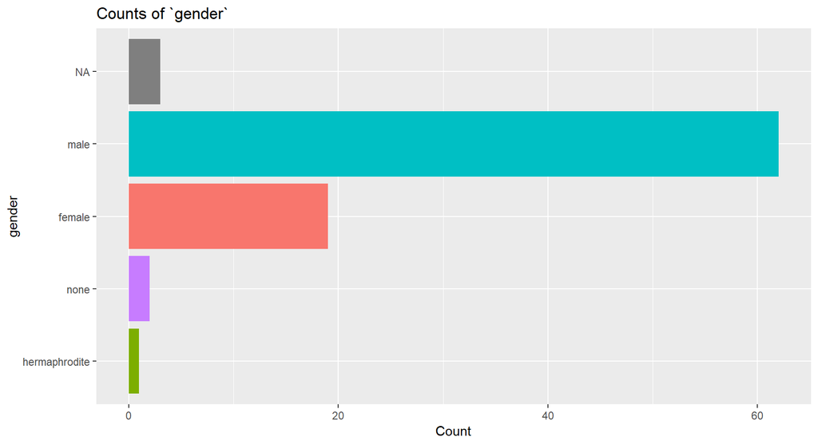

## homeworld

Counts and Proportion for Top 10: homeworld

| homeworld | n | percent |
| --- | --- | --- |
| Naboo | 11 | 12.64 |
| Tatooine | 10 | 11.49 |
| NA | 10 | 11.49 |
| Alderaan | 3 | 3.45 |
| Coruscant | 3 | 3.45 |
| Kamino | 3 | 3.45 |
| Corellia | 2 | 2.30 |
| Kashyyyk | 2 | 2.30 |
| Mirial | 2 | 2.30 |
| Ryloth | 2 | 2.30 |

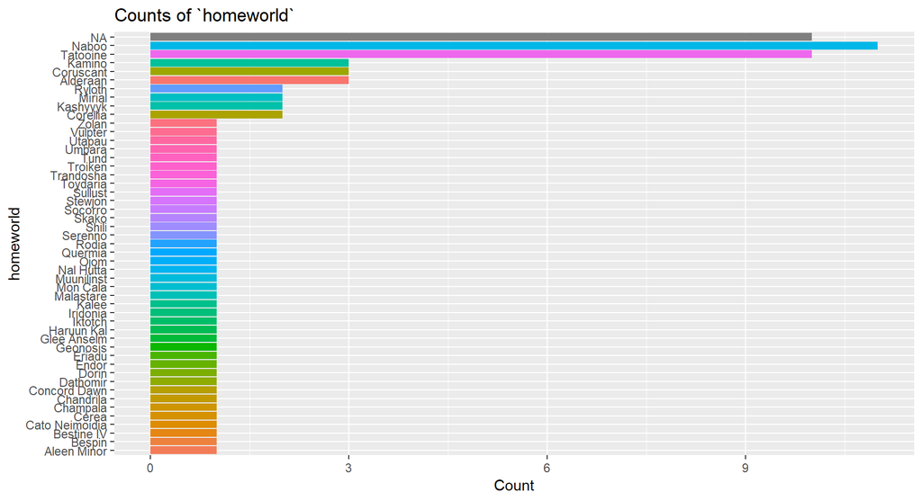

## species

Counts and Proportion for Top 10: species

| species | n | percent |
| --- | --- | --- |
| Human | 35 | 40.23 |
| Droid | 5 | 5.75 |
| NA | 5 | 5.75 |
| Gungan | 3 | 3.45 |
| Kaminoan | 2 | 2.30 |
| Mirialan | 2 | 2.30 |
| Twi’lek | 2 | 2.30 |
| Wookiee | 2 | 2.30 |
| Zabrak | 2 | 2.30 |
| Aleena | 1 | 1.15 |

[figure not shown]

Process Time: 0.5 minutes  
R version 3.5.1 (2018-07-02)  
Report by the Centre for Global Health Research